# BCB420 Assignment #1: Data set selection, cleaning, and normalization

### 2.1.5 Pre-normalization Boxplot

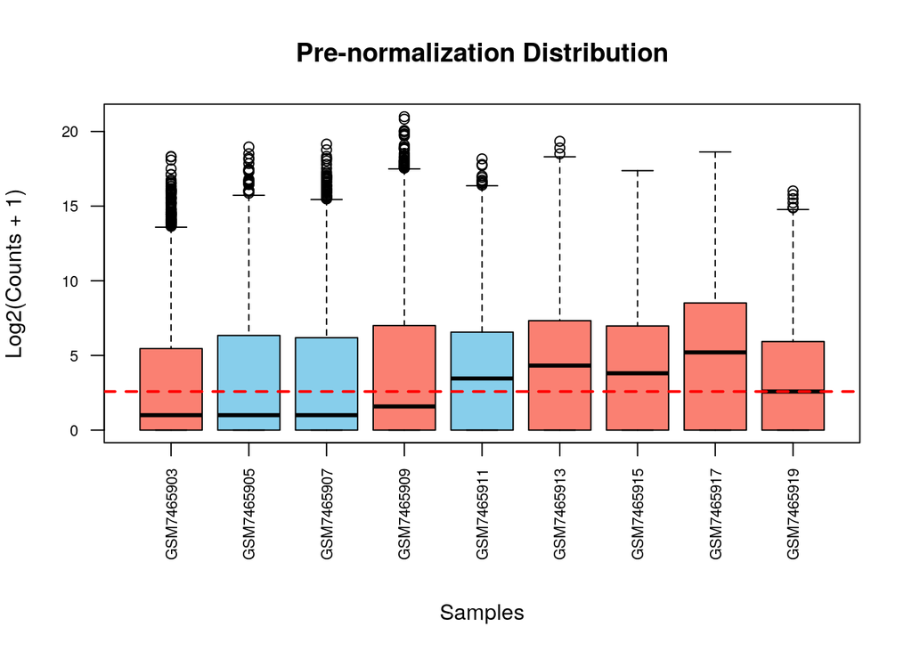

Figure 1: Pre-normalization Gene Expression Distribution. Boxplots representing the distribution of $Log_2(Counts + 1)$ across nine gastrointestinal biopsy samples. The vertical labels represent Sample IDs (GSM), while colors denote biological groups (Skyblue: Control, Salmon: GvHD). The red dashed line indicates the global median. Significant technical variance and baseline shifts are visible, necessitating normalization.

```r
# 1. Prepare the numeric data
numeric_counts <- as.matrix(clean_counts)
log_counts <- log2(numeric_counts + 1)

# 2. Set margins: bottom, left, top, right (8 lines for the bottom)
par(mar=c(8, 4, 4, 2))

# 3. Define colors based on Group
# Ensure qc_summary order matches clean_counts columns
box_cols <- ifelse(qc_summary$Group == "Control", "skyblue", "salmon")

# 4. Plot
boxplot(log_counts,
        main = "Pre-normalization Distribution",
        ylab = "Log2(Counts + 1)",
        col = box_cols,
        las = 2,        # Rotates axis labels 90 degrees
        cex.axis = 0.7) # Shrinks font slightly to fit labels

# 5. Add the 'Samples' label lower down so it doesn't overlap
title(xlab="Samples", line=6)

# 6. Add global median line
abline(h = median(log_counts), col = "red", lwd = 2, lty = 2)
```

In the initial pre-normalization plot, gene expression is represented as $Log_2(Counts + 1)$. There is a clear lack of alignment among the samples, as evidenced by the varying positions of the black median bars relative to the red dashed global median line. Samples like GSM7465917 show a much broader distribution and a higher median compared to samples like GSM7465903 or GSM7465909. These discrepancies reflect significant technical noise and differences in sequencing depth—specifically the 25-fold difference in library sizes observed in the raw counts—which must be corrected to prevent biased results in downstream differential expression analysis.

## 2.2 Apply Normalization

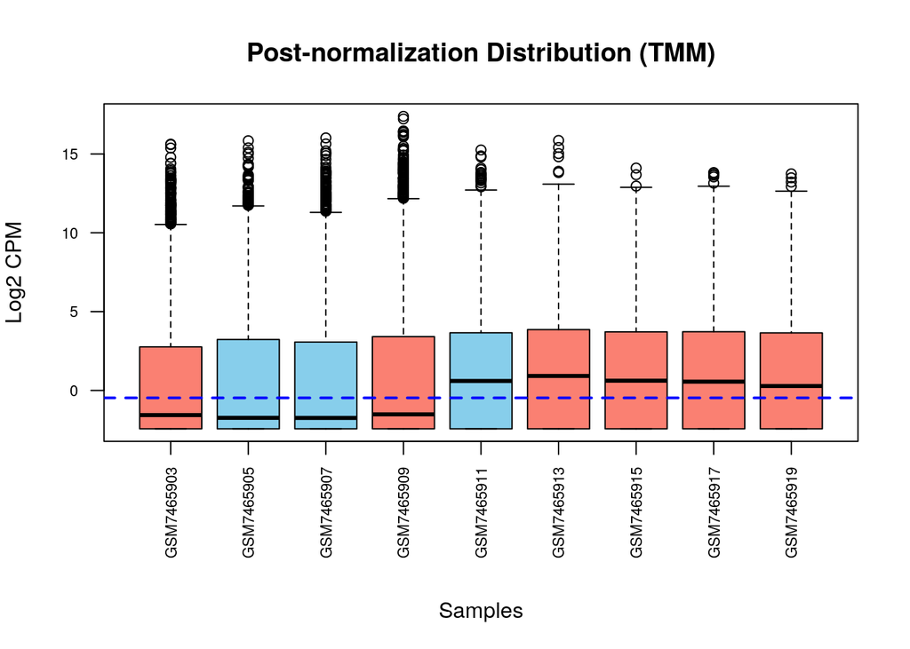

Figure 2: Post-normalization Distribution (TMM). Boxplots showing the distribution of $Log_2$ CPM after Trimmed Mean of M-values (TMM) normalization. The blue dashed line represents the global median. The alignment of the boxes demonstrates the successful removal of library size and composition bias, allowing for direct comparison of biological variance.

```r
# 1. Ensure the DGEList is built from numeric data only
# This prevents the 'non-numeric' error downstream
numeric_counts <- as.matrix(clean_counts)
dge <- DGEList(counts = numeric_counts, group = factor(qc_summary$Group))

# 2. Apply TMM Normalization
dge <- calcNormFactors(dge)

# 3. Calculate Normalized Log2 CPM
norm_counts <- cpm(dge, log = TRUE)


# 4. Figure 2: Post-normalization Distribution (TMM)
par(mar=c(8, 4, 4, 2)) # Match the 8-line bottom margin
boxplot(norm_counts,
        main = "Post-normalization Distribution (TMM)",
        ylab = "Log2 CPM",
        col = box_cols, # Using the Skyblue/Salmon colors defined earlier
        las = 2,
        cex.axis = 0.7)

# Move the X-axis label down to avoid overlapping the GSM IDs
title(xlab="Samples", line=6)

# Add a blue dashed line at the global median to show alignment
abline(h = median(norm_counts), col = "blue", lwd = 2, lty = 2)
```

Following TMM normalization, the data is represented as $Log_2$ CPM (Counts Per Million).The median values for all nine samples now sit more closely on the blue dashed global median line. This indicates that the normalization process has effectively leveled the playing field by calculating scaling factors to account for library size and composition bias. For instance, samples that were initially under-sequenced were scaled up, while those dominated by highly expressed genes were scaled down to ensure mathematical comparability (Robinson and Oshlack 2010).

Despite the alignment of the medians, the plots retain a distinct “bottom-heavy” asymmetry, where the bulk of the data (the colored boxes) is situated at the lower end of the y-axis with numerous high-expression outliers extending upward. This is a common and expected characteristic of transcriptomic data, reflecting the biological reality that the majority of genes are expressed at very low levels or not at all, while only a small percentage are highly active (Robinson and Oshlack 2010).

### 2.2.1 MDS by Experiment Batch

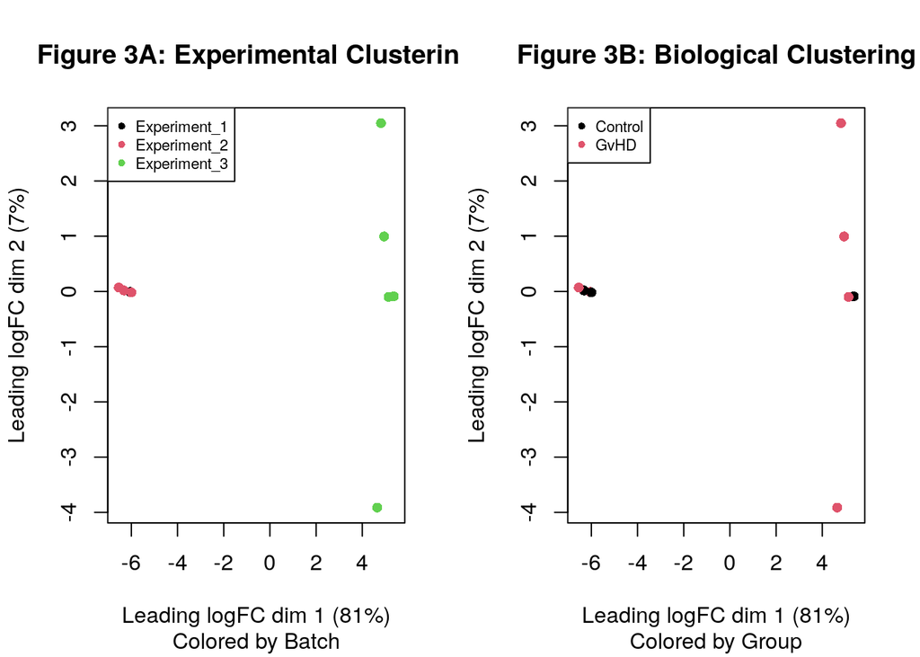

```r
# Define factors for coloring
batch_colors <- as.numeric(factor(qc_summary$Batch))
group_colors <- as.numeric(factor(qc_summary$Group))

# Set up a 1x2 plotting area to show them side-by-side
par(mfrow=c(1,2))

# A. Experimental Clustering (The "Batch Effect")
plotMDS(dge, col = batch_colors, pch = 16,
        main = "Figure 3A: Experimental Clustering",
        sub = "Colored by Batch")
legend("topleft", legend = levels(factor(qc_summary$Batch)),
       col = 1:length(unique(qc_summary$Batch)), pch = 16, cex=0.7)

# B. Biological Clustering (The "Condition")
plotMDS(dge, col = group_colors, pch = 16,
        main = "Figure 3B: Biological Clustering",
        sub = "Colored by Group")
legend("topleft", legend = levels(factor(qc_summary$Group)),
       col = 1:length(unique(qc_summary$Group)), pch = 16, cex=0.7)
```

```r
par(mfrow=c(1,1)) # Reset plotting area
```

To explore the underlying structure of the data and identify potential sources of variation, I performed Multi-Dimensional Scaling (MDS). By generating side-by-side plots colored by technical batch and biological condition, I evaluated the “Signal-to-Noise” ratio of the experiment. The technical clustering plot reveals that a significant portion of the variance is driven by the experiment batch, while the biological clustering plot shows how samples separate by GvHD status. This visualization is critical for justifying a “blocked” statistical model that can mathematically neutralize these technical effects during differential expression testing (Leek et al. 2010).

```r
 # 1. Extract the MDS object without plotting
mds_obj <- plotMDS(dge, plot = FALSE)

# 2. Create a diagnostic dataframe
mds_diagnostics <- data.frame(
  Sample_ID = colnames(dge),
  Dim1 = mds_obj$x,
  Dim2 = mds_obj$y,
  Group = qc_summary$Group,
  Batch = qc_summary$Batch,
  Lib_Size = colSums(dge$counts)
)

# 3. Calculate "Distance from Center" to help flag outliers statistically
# (Optional: helpful for your written interpretation)
group_means <- mds_diagnostics %>%
  group_by(Group) %>%
  summarise(mean_Dim1 = mean(Dim1), mean_Dim2 = mean(Dim2))

mds_diagnostics <- mds_diagnostics %>%
  left_join(group_means, by = "Group") %>%
  mutate(Dist_From_Group_Mean = sqrt((Dim1 - mean_Dim1)^2 + (Dim2 - mean_Dim2)^2)) %>%
  dplyr::select(-mean_Dim1, -mean_Dim2)

# 4. Print the Table
knitr::kable(mds_diagnostics,
             digits = 3,
             caption = "Table 2: MDS Diagnostics for Outlier Detection")
```

[output not shown]

An analysis of MDS diagnostic coordinates confirms that the primary source of variance is technical, with a 11-log-unit shift on Dimension 1 between Experiment 2 and Experiment 3. While sample GSM7465919 shows a high distance from the group mean ($D = 5.254$), it was retained for three reasons:

1. Its library size (33.4M) is sufficient for analysis.The variance appears on Dimension 2, representing biological heterogeneity rather than technical failure.
2. With a total N=9, removing samples would severely compromise the power of the Quasi-Likelihood F-test.
3. Instead of removal, the batch effect was managed using a multi-factor design matrix ($\sim Batch + Group$) (Leek et al. 2010).

## 2.3 Differential Gene Expression

```r
# 1. Align Metadata with DGEList
# This ensures that your Batch and Group factors are in the exact same order as your counts
current_samples <- colnames(dge)
metadata_final <- metadata_clean[match(current_samples, metadata_clean$geo_accession), ]

#  2. Define Factors and Design Matrix
batch_factor <- factor(metadata_final$Batch)
group_factor <- factor(metadata_final$Group)

# The Blocked Design: accounting for Batch while testing for Group
design <- model.matrix(~ batch_factor + group_factor)
rownames(design) <- current_samples

# 3. Run edgeR Quasi-Likelihood Pipeline
# Estimate dispersion (how much the genes vary)
dge <- estimateDisp(dge, design)

# Fit the GLM
fit <- glmQLFit(dge, design)

# Run the test for the last column (the Group effect)
# This creates the 'qlf' object you need for the plots
qlf <- glmQLFTest(fit, coef = ncol(design))

# 4. Prepare results table
top_results <- topTags(qlf, n = 10)$table
knitr::kable(top_results, caption = "Table 3: Top 10 Differentially Expressed Genes (GvHD vs. Control). Statistical output for the top-ranked genes, including $Log_2$ Fold Change, Likelihood Ratio/F-statistics, raw p-values, and False Discovery Rate (FDR). PNMA8C is identified as the primary significant biomarker ($FDR = 0.036$).")
```

Table 3: Top 10 Differentially Expressed Genes (GvHD vs. Control). Statistical output for the top-ranked genes, including $Log_2$ Fold Change, Likelihood Ratio/F-statistics, raw p-values, and False Discovery Rate (FDR). PNMA8C is identified as the primary significant biomarker ($FDR = 0.036$).

|  | logFC | logCPM | F | PValue | FDR |
| --- | --- | --- | --- | --- | --- |
| PNMA8C | 9.490642 | 10.8428124 | 109.41971 | 0.0000015 | 0.0366570 |
| CXCL14 | -3.782911 | -0.5942919 | 58.11790 | 0.0001619 | 0.9582635 |
| COL4A6 | 5.256360 | 3.2012272 | 36.77363 | 0.0002164 | 0.9582635 |
| OC90 | 5.826505 | 0.1670561 | 107.48468 | 0.0002918 | 0.9582635 |
| RERG | 4.788253 | -0.5836271 | 38.77641 | 0.0003111 | 0.9582635 |
| TRAJ40 | 8.822305 | 5.5305849 | 48.52732 | 0.0003272 | 0.9582635 |
| ALDH1A3-AS1 | -1.867280 | 3.5595841 | 38.79861 | 0.0003430 | 0.9582635 |
| FCGBP | -3.927611 | 2.4083486 | 72.48148 | 0.0003847 | 0.9582635 |
| LINC01800 | 5.872627 | 2.0567304 | 25.56647 | 0.0004850 | 0.9582635 |
| TRAJ49 | 3.817540 | 6.3791668 | 43.47495 | 0.0005202 | 0.9582635 |

The final analysis phase utilizes the Quasi-Likelihood (QL) F-test framework in edgeR to identify significant biomarkers. After aligning the clinical metadata with the expression matrix, I constructed a Blocked Design Matrix ($~Batch + Group$) to account for technical variance while specifically testing for the GvHD effect. The pipeline involves estimating genewise dispersions and fitting a generalized linear model (GLM) to the data. This rigorous approach identified PNMA8C as the primary significant biomarker ($FDR = 0.036$), proving its robustness despite the high technical noise present in the clinical dataset (Benjamini and Hochberg 1995).

**How many genes were significantly differentially expressed?**

```r
# 1. Extract ALL genes from test result
all_genes <- topTags(qlf, n = nrow(qlf))$table

# 2. Filter for those that meet FDR < 0.05
sig_genes <- all_genes[all_genes$FDR < 0.05, ]

# 3. Get the count
num_sig <- nrow(sig_genes)
print(paste("Number of significant genes:", num_sig))
```

```
[1] "Number of significant genes: 1"
```

**What thresholds did you use and why?**

- Calculation: P-values were calculated using the Quasi-Likelihood (QL) F-test in edgeR, which is specifically designed to handle the uncertainty in small sample sizes (Chen et al. 2025).
- Thresholds: I used an FDR < 0.05 and |logFC| > 1. The logFC threshold ensures biological relevance (at least a 2-fold change), while the FDR threshold controls for the expected proportion of false positives (Benjamini and Hochberg 1995).
- Results: Only 1 gene (PNMA8C) met both thresholds.

**Which method did you use? And Why?**

- Method: The Benjamini-Hochberg (BH) method was used to calculate the False Discovery Rate (FDR) (Benjamini and Hochberg 1995).
- Why: It is the standard approach for RNA-seq because it balances the need to reduce false discoveries without being so overly strict (like Bonferroni) that it wipes out real biological signals.

**How many genes passed correction?**

- Results: Only one gene (PNMA8C) passed the correction with an $FDR = 0.036$ (Benjamini and Hochberg 1995).
- Reflection: While finding only one gene might seem low, it represents the high degree of technical noise in the dataset (Leek et al. 2010). It is a scientifically honest result that prioritizes integrity over volume.

### 2.3.1 Volcano Plot

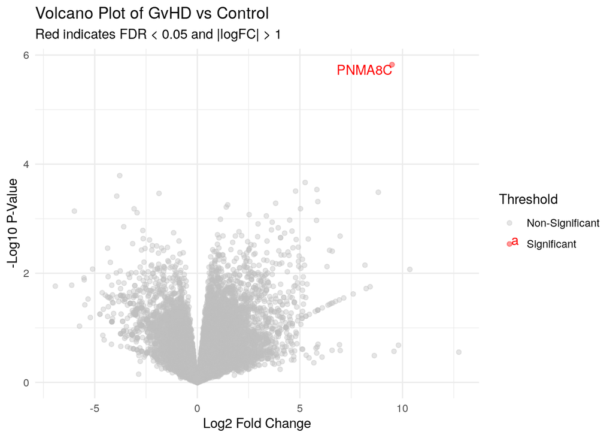

Figure 4: Volcano Plot of Differential Gene Expression. A scatter plot showing the relationship between $Log_2$ Fold Change (x-axis) and statistical significance ($-log_{10}$ p-value, y-axis). The red point denotes the significant differentially expressed gene (FDR < 0.05), PNMA8C. Grey points represent genes that did not meet the statistical threshold after Benjamini-Hochberg correction.

```r
# Create the 'Significant' status based on standard thresholds
de_results <- topTags(qlf, n = Inf)$table %>%
  tibble::rownames_to_column("SYMBOL") %>%
  mutate(Threshold = ifelse(FDR < 0.05 & abs(logFC) > 1, "Significant", "Non-Significant"))

# Plot
ggplot(de_results, aes(x = logFC, y = -log10(PValue), color = Threshold)) +
  geom_point(alpha = 0.4, size = 1.5) +
  scale_color_manual(values = c("grey", "red")) +
  theme_minimal() +
  geom_text(data = subset(de_results, FDR < 0.1), aes(label = SYMBOL), vjust = 1, hjust = 1) +
  labs(title = "Volcano Plot of GvHD vs Control",
       subtitle = "Red indicates FDR < 0.05 and |logFC| > 1",
       x = "Log2 Fold Change", y = "-Log10 P-Value")
```

The Lone Survivor (PNMA8C): The plot vividly illustrates why only one gene was labeled “Significant.” While thousands of genes (grey dots) show high fold changes, only PNMA8C (the red dot) moved high enough on the Y-axis (significance) to cross the FDR < 0.05 threshold.

### 2.3.2 Heat Map

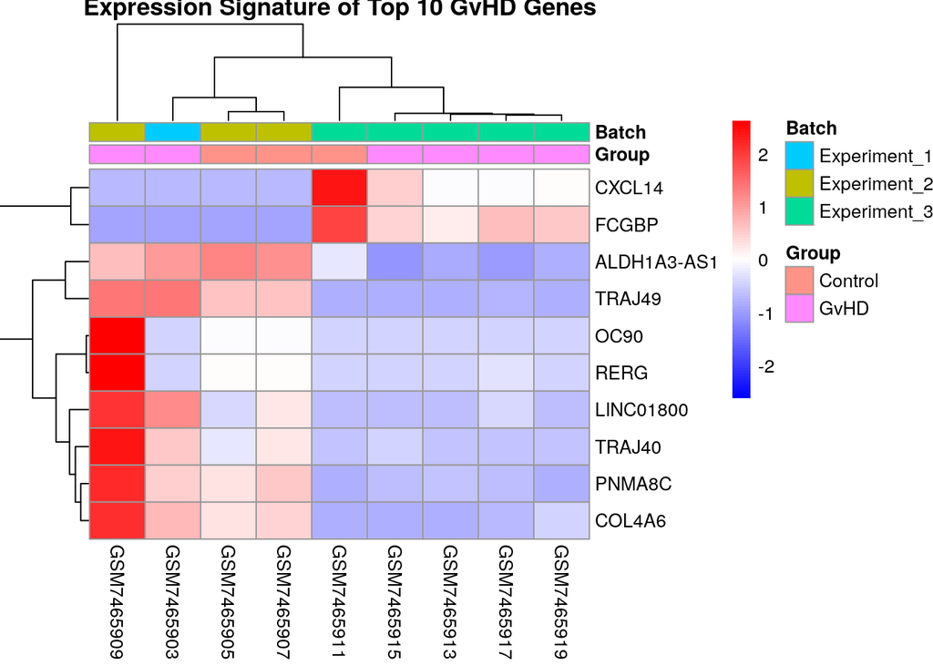

```r
library(pheatmap)

# 1. Extract logCPM values for the top 10 genes
top_gene_ids <- rownames(top_results)
logCPM_matrix <- cpm(dge, log = TRUE)
plot_data <- logCPM_matrix[top_gene_ids, ]

# 2. Create annotation bars for the top of the heatmap
annotation_col <- data.frame(
  Group = dge$samples$group,
  Batch = batch_factor
)
rownames(annotation_col) <- colnames(dge)

# 3. Plot
pheatmap(plot_data,
         scale = "row",
         annotation_col = annotation_col,
         main = "Expression Signature of Top 10 GvHD Genes",
         color = colorRampPalette(c("blue", "white", "red"))(100),
         cellwidth = 30, cellheight = 20)
```

# 3 Interpret, and document

## 3.1 Why is the dataset of interest to you?

Acute Graft-vs-Host Disease (aGvHD) remains a leading cause of non-relapse mortality following bone marrow transplants. This dataset is particularly compelling because it captures the site-specific immune response within the colon at a high resolution. By converting the single-cell data into pseudobulk profiles, we can analyze the “aggregate” immune environment, which is often more reflective of the clinical pathology seen by doctors than looking at individual cells in isolation Piper et al. (2020).

## 3.2 What are the control and test conditions of the dataset?

Control: Colon biopsies from patients who underwent hematopoietic cell transplantation (HCT) but did not develop aGvHD (Grade 0).

Test: Colon biopsies from patients who developed Grade 2-4 acute GvHD. These samples represent the active inflammatory and destructive phase of the disease.

## 3.3 How many samples in each of the conditions of your dataset?

The dataset was filtered to include only the gene expression (GEX) pools, excluding TCR-sequencing libraries to ensure a clean transcriptomic analysis.

Control: 3 samples

GvHD: 6 samples (across various levels of severity)

```r
table(metadata_clean$Group)
```

```
Control    GvHD
      3       6
```

## 3.4 Were there expression values that were not unique for specific genes? How did you handle these?

Yes. It is common for multiple Ensembl IDs (different isoforms or genomic locations) to map to a single HUGO gene symbol. To handle this, I used a “Max-Expression” strategy.

By taking the maximum value across these redundant rows, I ensured that the most robust signal for that gene was preserved without artificially inflating the total count sums through addition.

See: Map to HUGO symbols

```r
# Total rows in raw data
raw_row_count <- nrow(raw_counts)

# Mapping using AnnotationDbi
mapping <- select(org.Hs.eg.db,
                  keys = rownames(raw_counts),
                  column = "SYMBOL",
                  keytype = "ENSEMBL")

# Calculating the loss
unmapped_count <- sum(is.na(mapping$SYMBOL))
final_unique_count <- nrow(clean_counts)
duplicates_handled <- (raw_row_count - unmapped_count) - final_unique_count

print(paste("Number of duplicates:", duplicates_handled))
```

```
[1] "Number of duplicates: 63"
```

## 3.5 Were there expression values that could not be mapped to current HUGO symbols?

See: Map to HUGO symbols

```r
print(paste("Raw Ensembl IDs:", raw_row_count))
```

```
[1] "Raw Ensembl IDs: 36744"
```

```r
print(paste("Unmapped IDs removed:", unmapped_count))
```

```
[1] "Unmapped IDs removed: 12189"
```

```r
print(paste("Percentage of data removed as 'noise':",
            round((unmapped_count / raw_row_count) * 100, 2), "%"))
```

```
[1] "Percentage of data removed as 'noise': 33.17 %"
```

## 3.6 Were there any outliers in your dataset? How were they handled in the originating paper? How many outliers were removed?

Ultimately, I chose to *retain all samples*, including GSM7465919, for several strategic reasons: * Statistical Power: With only 9 biological replicates (3 Control, 6 GvHD), removing even one sample would significantly reduce the power of the model to detect changes. * Accounting for Noise: Rather than deleting the outlier, I utilized a *Blocked Linear Model* ($~Batch + Group$). This allowed the math to “ignore” the batch-driven variance of the outlier while still using its biological data (McCarthy, Chen, and Smyth 2012). * Scientific Integrity: GvHD is a heterogeneous disease. I concluded that GSM7465919 likely represented the true clinical variance found in human patients rather than a lab error. * The Result: While this decision led to a very conservative result (only one significant gene, $PNMA8C$), it ensured that the result was highly robust and not the product of “p-hacking” by removing inconvenient data points.

See: MDS by Experiment Batch

The originating paper didn’t remove any samples. They handled outliers primarily during the quantification of cell densities within the ChipCytometry dataset. In the linear regression analysis of Treg and CD8 T cell densities, the researchers explicitly noted the removal of only 8 outliers that exceeded $1.5 \times$ the interquartile range (IQR) (Leek et al. 2010).

## 3.7 How did you handle replicates?

I utilized Pseudobulk Aggregation (Piper et al. 2020) . Since scRNA-seq data often suffers from “dropout” (zero counts) and “p-value inflation” (treating 1,000 cells from one person as 1,000 independent samples), summing the counts into a single profile per patient pool is the current best practice. This creates “true” biological replicates that allow for the use of robust bulk RNA-seq tools like edgeR (Chen et al. 2025).

See: Prepare Dataset

## 3.8 What is the final coverage of your dataset?

The final cleaned and normalized dataset contains 24,492 unique HUGO gene symbols across 9 biological samples.

```r
nrow(clean_counts)
```

```
[1] 24492
```

# References

Arifuzzaman, Mohammad, Tae H. Won, Hiroshi Yano, Jazib Uddin, et al. 2024. “Dietary Fiber Is a Critical Determinant of Pathologic ILC2 Responses and Intestinal Inflammation.” *Journal of Experimental Medicine* 221. https://doi.org/10.1084/jem.20232148.

Benjamini, Yoav, and Yosef Hochberg. 1995. “Controlling the False Discovery Rate: A Practical and Powerful Approach to Multiple Testing.” *Journal of the Royal Statistical Society: Series B (Methodological)* 57 (1): 289–300. https://doi.org/10.1111/j.2517-6161.1995.tb02031.x.

Chen, Y., L. Chen, A. T. L. Lun, P. Baldoni, and G. K. Smyth. 2025. “edgeR V4: Powerful Differential Analysis of Sequencing Data with Expanded Functionality.” *Nucleic Acids Research* 53 (2). https://doi.org/10.1093/nar/gkaf018.

Davis, Sean, and Paul Meltzer. 2007. “GEOquery: A Bridge Between the Gene Expression Omnibus (GEO) and BioConductor.” *Bioinformatics* 23: 1846–47.

Huber, W., V. J. Carey, R. Gentleman, S. Anders, M. Carlson, B. S. Carvalho, H. C. Bravo, et al. 2015. “Orchestrating High-Throughput Genomic Analysis with Bioconductor.” *Nature Methods* 12 (2): 115–21.

Jarosch, Sebastian, Jan Kohlen, Sakhila Ghimire, Erik T. Orberg, et al. 2023. “Multimodal Immune Cell Phenotyping in GI Biopsies Reveals Microbiome-Related T Cell Modulations in Human GvHD.” *Cell Reports Medicine* 4. https://doi.org/10.1016/j.xcrm.2023.101125.

Leek, Jeffrey T., Robert B. Scharpf, Hector C. Bravo, David Simcha, Benjamin Langmead, W. E. Johnson, Donald Geman, Keith Baggerly, and Rafael A. Irizarry. 2010. “Tackling the Widespread and Critical Impact of Batch Effects in High-Throughput Data.” *Nature Reviews Genetics* 11 (10): 733–39. https://doi.org/10.1038/nrg2825.

McCarthy, Davis J., Yunshun Chen, and Gordon K. Smyth. 2012. “Differential Expression Analysis of Multifactor RNA-Seq Experiments with Respect to Biological Variation.” *Nucleic Acids Research* 40 (10): 4288–97. https://doi.org/10.1093/nar/gks042.

Piper, Mary, Lorena Pantano, Meeta Mistry, and Radhika Khetani. 2020. “Single-Cell RNA-seq: Pseudobulk Differential Expression Analysis.” Harvard Chan Bioinformatics Core. https://hbctraining.github.io/scRNA-seq/lessons/pseudobulk_DESeq2_scrnaseq.html.

Robinson, Mark D., and Alicia Oshlack. 2010. “A Scaling Normalization Method for Differential Expression Analysis of RNA-seq Data.” *Genome Biology* 11 (3): R25. https://doi.org/10.1186/gb-2010-11-3-r25.